# Shortened Removed: results02_population-accuracy-stats

Tommy Botch

2025-10-02

# Setup environment

## Load packages and setup paths for analysis

Set up directories - since we’re doing this locally (and mounting the server), we’re going to use a different base_dir

# Population-level analysis

## Data loading

Load data and set factors. Our columns are the following: - **modality:** which modality was the stimulus presented as (video, audio, text) - **ground_truth:** ground-truth word to be predicted - **top_pred:** most predicted word across the population - **word_index:** the word index within the story - **task:** which of the three stories was the data from (black, wheretheressmoke, howtodraw)

We create a contrast of modality such that we test the hypothesis that multimodal (video) > spoken (audio) > written (text).

```r
results_fn <- file.path(results_dir, "all-task_group-analyzed-behavior_human-lemmatized.csv")

# Load data and convert columns to factors
df_results <- load_and_prepare_data(
  file_path=results_fn,
  factor_columns=c('modality', 'ground_truth', 'top_pred', 'word_index', 'task', "POS_spaCy", "Clause_Pos", "Clause_ID")
)

# Set the levels for the modality column
df_results <- set_factor_levels(
  df=df_results,
  column_name="modality",
  levels=c("video", "audio", "text")
)

df_results <- create_column_contrast(
  df=df_results,
  column_name="modality"
)

# Drop multiple columns
df_results <- df_results %>% select(-c(prominence, boundary))

colnames(df_results)
```

```
##  [1] "modality"
##  [2] "word_index"
##  [3] "ground_truth"
##  [4] "top_pred"
##  [5] "accuracy"
##  [6] "predictability"
##  [7] "top_prob"
##  [8] "n_predictions"
##  [9] "entropy"
## [10] "normalized_entropy"
## [11] "bert_top_word_accuracy"
## [12] "fasttext_top_word_accuracy"
## [13] "fasttext_avg_accuracy"
## [14] "fasttext_max_accuracy"
## [15] "fasttext_weighted_pred.gt_accuracy"
```

[output cut: 48 more lines]

## Analysis 1A - Population-level binary accuracy

We now aggregate predictions into a distribution across subjects, and find the most commonly predicted word for participants within each condition. We then predicted the binary accuracy (one-shot accuracy) based on the modality of presentation (condition) while controlling for random effects of trial (word_index) within each task (story).

Given that accuracy is a binary measure (0/1), we used a logistic mixed-effects model.

```r
binary_accuracy_formula <- 'accuracy ~ modality + (1|word_index:task)'

# Fit the logistic mixed-effects model
model <- glmer(binary_accuracy_formula,
               data = df_results,
               family = binomial(link = "logit"))

tab_model(model, show.se=TRUE, show.stat=TRUE, show.r2=TRUE, show.df=TRUE)
```

|  | accuracy |  |  |  |  |  |
| --- | --- | --- | --- | --- | --- | --- |
| Predictors | Odds Ratios | std. Error | CI | Statistic | p | df |
| (Intercept) | 0.52 | 0.11 | 0.35 – 0.78 | -3.14 | **0.002** | Inf |
| modality L | 0.24 | 0.04 | 0.18 – 0.32 | -9.45 | **<0.001** | Inf |
| modality Q | 0.74 | 0.10 | 0.57 – 0.96 | -2.24 | **0.025** | Inf |
| Random Effects |  |  |  |  |  |  |
| σ<sup>2</sup> | 3.29 |  |  |  |  |  |
| τ<sub>00</sub> <sub>word_index:task</sub> | 16.24 |  |  |  |  |  |
| ICC | 0.83 |  |  |  |  |  |
| N <sub>word_index</sub> | 594 |  |  |  |  |  |
| N <sub>task</sub> | 3 |  |  |  |  |  |
| Observations | 2016 |  |  |  |  |  |
| Marginal R<sup>2</sup> / Conditional R<sup>2</sup> | 0.036 / 0.838 |  |  |  |  |  |

```r
# Display results of fixed effects
display_model_summary(model)
```

Model Fixed Effects Summary

| Predictor | Fixed Effects Results Coefficient Estimate | Fixed Effects Results Standard Error | Fixed Effects Results Z-Statistic | Fixed Effects Results P-Value |
| --- | --- | --- | --- | --- |
| (Intercept) | -0.6450581 | 0.2051598 | -3.144174 | 1.665562e-03 |
| modality.L | -1.4429856 | 0.1526945 | -9.450151 | 3.383439e-21 |
| modality.Q | -0.2959313 | 0.1320326 | -2.241351 | 2.500335e-02 |

```r
# Conduct pairwise comparisons between modalities
pairwise_comparisons <- emmeans(model, pairwise ~ modality)
display_pairwise_comparisons(pairwise_comparisons)
```

Pairwise Comparisons

| Comparison Results Comparison | Comparison Results Difference in Mean | Comparison Results Standard Error | Comparison Results Degrees of Freedom | Comparison Results Z-Statistic | Comparison Results P-Value |
| --- | --- | --- | --- | --- | --- |
| video - audio | 0.6579046 | 0.1866180 | Inf | 3.525408 | 1.229653e-03 |
| video - text | 2.0406898 | 0.2159426 | Inf | 9.450151 | 2.653433e-14 |
| audio - text | 1.3827852 | 0.2019582 | Inf | 6.846890 | 2.266454e-11 |

### Analysis 1B - Prosody interaction with binary accuracy

We can also look at whether the average prosody (prominence) leading up to a to-be-predicted word exhibits an interaction with modality. We therefore run an additional model investigating whether the two are related.

```r
binary_accuracy_formula <- 'accuracy ~ modality * prominence_mean_words5 + (1|word_index:task)'

# Fit the logistic mixed-effects model
model <- glmer(binary_accuracy_formula,
               data = df_results,
               family = binomial(link = "logit"))

tab_model(model, show.se=TRUE, show.stat=TRUE, show.r2=TRUE, show.df=TRUE)
```

|  | accuracy |  |  |  |  |  |
| --- | --- | --- | --- | --- | --- | --- |
| Predictors | Odds Ratios | std. Error | CI | Statistic | p | df |
| (Intercept) | 0.40 | 0.16 | 0.18 – 0.89 | -2.26 | **0.024** | Inf |
| modality L | 0.58 | 0.17 | 0.33 – 1.02 | -1.91 | 0.057 | Inf |
| modality Q | 0.94 | 0.25 | 0.56 – 1.58 | -0.24 | 0.813 | Inf |
| prominence mean words5 | 1.68 | 1.16 | 0.43 – 6.50 | 0.75 | 0.455 | Inf |
| modality L × prominence mean words5 | 0.14 | 0.08 | 0.05 – 0.42 | -3.54 | **<0.001** | Inf |
| modality Q × prominence mean words5 | 0.61 | 0.29 | 0.24 – 1.55 | -1.04 | 0.298 | Inf |
| Random Effects |  |  |  |  |  |  |
| σ<sup>2</sup> | 3.29 |  |  |  |  |  |
| τ<sub>00</sub> <sub>word_index:task</sub> | 17.03 |  |  |  |  |  |
| ICC | 0.84 |  |  |  |  |  |
| N <sub>word_index</sub> | 594 |  |  |  |  |  |
| N <sub>task</sub> | 3 |  |  |  |  |  |
| Observations | 2016 |  |  |  |  |  |
| Marginal R<sup>2</sup> / Conditional R<sup>2</sup> | 0.042 / 0.845 |  |  |  |  |  |

```r
# Display results of fixed effects
display_model_summary(model)
```

Model Fixed Effects Summary

| Predictor | Fixed Effects Results Coefficient Estimate | Fixed Effects Results Standard Error | Fixed Effects Results Z-Statistic | Fixed Effects Results P-Value |
| --- | --- | --- | --- | --- |
| (Intercept) | -0.91351649 | 0.4043795 | -2.2590571 | 0.0238798326 |
| modality.L | -0.54058244 | 0.2836902 | -1.9055382 | 0.0567101449 |
| modality.Q | -0.06242417 | 0.2640372 | -0.2364219 | 0.8131053287 |
| prominence_mean_words5 | 0.51644665 | 0.6915865 | 0.7467564 | 0.4552106268 |
| modality.L:prominence_mean_words5 | -1.94277673 | 0.5492010 | -3.5374604 | 0.0004039947 |
| modality.Q:prominence_mean_words5 | -0.50019816 | 0.4801544 | -1.0417445 | 0.2975301737 |

```r
# Conduct pairwise comparisons between modalities
pairwise_comparisons <- emmeans(model, pairwise ~ modality)
```

```
## NOTE: Results may be misleading due to involvement in interactions
```

```r
display_pairwise_comparisons(pairwise_comparisons)
```

Pairwise Comparisons

| Comparison Results Comparison | Comparison Results Difference in Mean | Comparison Results Standard Error | Comparison Results Degrees of Freedom | Comparison Results Z-Statistic | Comparison Results P-Value |
| --- | --- | --- | --- | --- | --- |
| video - audio | 0.6734888 | 0.1888041 | Inf | 3.567131 | 1.051442e-03 |
| video - text | 2.0917751 | 0.2226249 | Inf | 9.395964 | 2.831069e-14 |
| audio - text | 1.4182863 | 0.2072723 | Inf | 6.842623 | 2.334954e-11 |

### Plot interaction model

```
## Data were 'prettified'. Consider using `terms="prominence_mean_words5
##   [all]"` to get smooth plots.
```

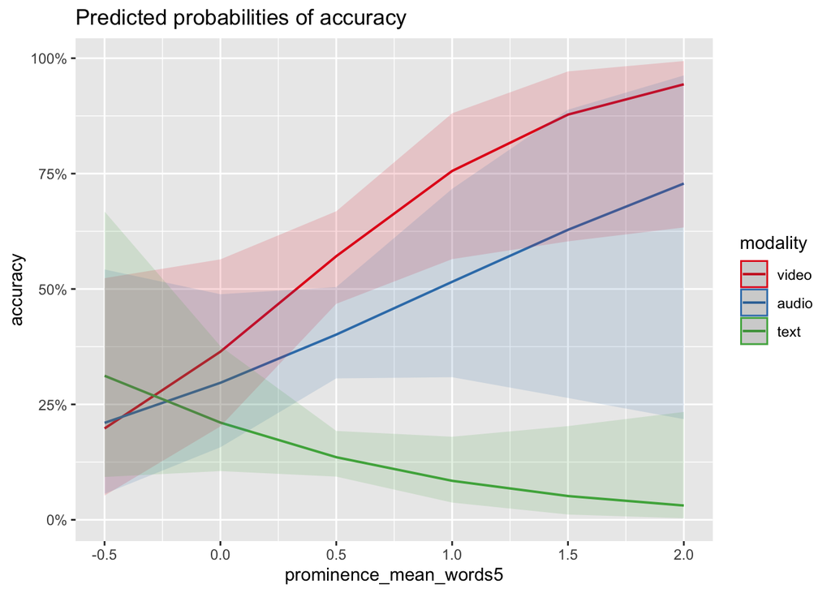

```r
plot_model(model, type="pred", terms=c("prominence_mean_words5", "modality"))
```

## Analysis 1C - Task-level comparisons (binary accuracy)

```r
binary_accuracy_formula <- 'accuracy ~ modality + (1|word_index)'
```

#### Story = Black

```r
model <- lmer_task(
  task_name='black',
  df=df_results,
  formula=binary_accuracy_formula,
  family=binomial(link="logit")
)

# Output the results
tab_model(model, show.se = TRUE, show.stat = TRUE, show.r2 = TRUE)
```

|  | Dependent variable |  |  |  |  |
| --- | --- | --- | --- | --- | --- |
| Predictors | Odds Ratios | std. Error | CI | Statistic | p |
| (Intercept) | 1.14 | 0.43 | 0.55 – 2.40 | 0.36 | 0.721 |
| modality L | 0.13 | 0.04 | 0.06 – 0.25 | -6.06 | **<0.001** |
| modality Q | 0.48 | 0.13 | 0.29 – 0.82 | -2.72 | **0.006** |
| Random Effects |  |  |  |  |  |
| σ<sup>2</sup> | 3.29 |  |  |  |  |
| τ<sub>00</sub> <sub>word_index</sub> | 17.79 |  |  |  |  |
| ICC | 0.84 |  |  |  |  |
| N <sub>word_index</sub> | 194 |  |  |  |  |
| Observations | 582 |  |  |  |  |
| Marginal R<sup>2</sup> / Conditional R<sup>2</sup> | 0.071 / 0.855 |  |  |  |  |

```r
# Display results of fixed effects
display_model_summary(model)
```

Model Fixed Effects Summary

| Predictor | Fixed Effects Results Coefficient Estimate | Fixed Effects Results Standard Error | Fixed Effects Results Z-Statistic | Fixed Effects Results P-Value |
| --- | --- | --- | --- | --- |
| (Intercept) | 0.1351198 | 0.3777440 | 0.3577019 | 7.205664e-01 |
| modality.L | -2.0697253 | 0.3415478 | -6.0598416 | 1.362556e-09 |
| modality.Q | -0.7256241 | 0.2664603 | -2.7231977 | 6.465336e-03 |

```r
# Conduct pairwise comparisons between modalities
pairwise_comparisons <- emmeans(model, pairwise ~ modality)
display_pairwise_comparisons(pairwise_comparisons)
```

Pairwise Comparisons

| Comparison Results Comparison | Comparison Results Difference in Mean | Comparison Results Standard Error | Comparison Results Degrees of Freedom | Comparison Results Z-Statistic | Comparison Results P-Value |
| --- | --- | --- | --- | --- | --- |
| video - audio | 0.5748125 | 0.3618009 | Inf | 1.588753 | 2.504633e-01 |
| video - text | 2.9270337 | 0.4830215 | Inf | 6.059842 | 4.086272e-09 |
| audio - text | 2.3522212 | 0.4458231 | Inf | 5.276131 | 3.951401e-07 |

#### Story = Smoke

```r
model <- lmer_task(
  task_name='wheretheressmoke',
  df=df_results,
  formula=binary_accuracy_formula,
  family=binomial(link="logit")
)

# Output the results
tab_model(model, show.se = TRUE, show.stat = TRUE, show.r2 = TRUE)
```

|  | Dependent variable |  |  |  |  |
| --- | --- | --- | --- | --- | --- |
| Predictors | Odds Ratios | std. Error | CI | Statistic | p |
| (Intercept) | 0.43 | 0.15 | 0.22 – 0.84 | -2.48 | **0.013** |
| modality L | 0.21 | 0.05 | 0.13 – 0.35 | -6.01 | **<0.001** |
| modality Q | 1.23 | 0.27 | 0.80 – 1.89 | 0.92 | 0.356 |
| Random Effects |  |  |  |  |  |
| σ<sup>2</sup> | 3.29 |  |  |  |  |
| τ<sub>00</sub> <sub>word_index</sub> | 15.30 |  |  |  |  |
| ICC | 0.82 |  |  |  |  |
| N <sub>word_index</sub> | 237 |  |  |  |  |
| Observations | 711 |  |  |  |  |
| Marginal R<sup>2</sup> / Conditional R<sup>2</sup> | 0.043 / 0.831 |  |  |  |  |

```r
# Display results of fixed effects
display_model_summary(model)
```

Model Fixed Effects Summary

| Predictor | Fixed Effects Results Coefficient Estimate | Fixed Effects Results Standard Error | Fixed Effects Results Z-Statistic | Fixed Effects Results P-Value |
| --- | --- | --- | --- | --- |
| (Intercept) | -0.8432406 | 0.3406832 | -2.4751461 | 1.331817e-02 |
| modality.L | -1.5636559 | 0.2600837 | -6.0121248 | 1.831073e-09 |
| modality.Q | 0.2037954 | 0.2208581 | 0.9227438 | 3.561407e-01 |

```r
# Conduct pairwise comparisons between modalities
pairwise_comparisons <- emmeans(model, pairwise ~ modality)
display_pairwise_comparisons(pairwise_comparisons)
```

Pairwise Comparisons

| Comparison Results Comparison | Comparison Results Difference in Mean | Comparison Results Standard Error | Comparison Results Degrees of Freedom | Comparison Results Z-Statistic | Comparison Results P-Value |
| --- | --- | --- | --- | --- | --- |
| video - audio | 1.3552691 | 0.3282317 | Inf | 4.129002 | 1.079250e-04 |
| video - text | 2.2113434 | 0.3678140 | Inf | 6.012125 | 5.491126e-09 |
| audio - text | 0.8560743 | 0.3259485 | Inf | 2.626410 | 2.345752e-02 |

#### Story = Draw

```r
model <- lmer_task(
  task_name='howtodraw',
  df=df_results,
  formula=binary_accuracy_formula,
  family=binomial(link="logit")
)

# Output the results
tab_model(model, show.se = TRUE, show.stat = TRUE, show.r2 = TRUE)
```

|  | Dependent variable |  |  |  |  |
| --- | --- | --- | --- | --- | --- |
| Predictors | Odds Ratios | std. Error | CI | Statistic | p |
| (Intercept) | 0.31 | 0.13 | 0.14 – 0.69 | -2.84 | **0.004** |
| modality L | 0.40 | 0.10 | 0.25 – 0.64 | -3.80 | **<0.001** |
| modality Q | 0.61 | 0.14 | 0.39 – 0.96 | -2.16 | **0.031** |
| Random Effects |  |  |  |  |  |
| σ<sup>2</sup> | 3.29 |  |  |  |  |
| τ<sub>00</sub> <sub>word_index</sub> | 19.07 |  |  |  |  |
| ICC | 0.85 |  |  |  |  |
| N <sub>word_index</sub> | 241 |  |  |  |  |
| Observations | 723 |  |  |  |  |
| Marginal R<sup>2</sup> / Conditional R<sup>2</sup> | 0.016 / 0.855 |  |  |  |  |

```r
# Display results of fixed effects
display_model_summary(model)
```

Model Fixed Effects Summary

| Predictor | Fixed Effects Results Coefficient Estimate | Fixed Effects Results Standard Error | Fixed Effects Results Z-Statistic | Fixed Effects Results P-Value |
| --- | --- | --- | --- | --- |
| (Intercept) | -1.1716962 | 0.4120588 | -2.843517 | 0.0044618632 |
| modality.L | -0.9200578 | 0.2421665 | -3.799277 | 0.0001451186 |
| modality.Q | -0.4911099 | 0.2277255 | -2.156587 | 0.0310378214 |

```r
# Conduct pairwise comparisons between modalities
pairwise_comparisons <- emmeans(model, pairwise ~ modality)
display_pairwise_comparisons(pairwise_comparisons)
```

Pairwise Comparisons

| Comparison Results Comparison | Comparison Results Difference in Mean | Comparison Results Standard Error | Comparison Results Degrees of Freedom | Comparison Results Z-Statistic | Comparison Results P-Value |
| --- | --- | --- | --- | --- | --- |
| video - audio | 0.04909475 | 0.3125728 | Inf | 0.1570666 | 0.9864915358 |
| video - text | 1.30115818 | 0.3424752 | Inf | 3.7992775 | 0.0004263219 |
| audio - text | 1.25206343 | 0.3413496 | Inf | 3.6679796 | 0.0007150321 |

## Analysis 2A - Population-level continuous accuracy

We next evaluate the semantic similarity of human predictions to the ground-truth word. We use fasttext as a semantic embedding space and calculate the cosine similarity between each prediction and the ground-truth word. This turns accuracy into a continuous metric (now referred to as “continuous accuracy”).

We use a linear mixed-effects model to predict continous accuracy based on the modality of presentation (condition) while controlling for random effects of trial (word_index) within each task (story).

```r
continuous_accuracy_formula <- 'fasttext_top_word_accuracy ~ modality + (1|word_index:task)'

# Fit the logistic mixed-effects model
model <- lmer(continuous_accuracy_formula, data=df_results)

tab_model(model, show.se=TRUE, show.stat=TRUE, show.r2=TRUE, show.df=TRUE)
```

|  | fasttext_top_word_accuracy |  |  |  |  |  |
| --- | --- | --- | --- | --- | --- | --- |
| Predictors | Estimates | std. Error | CI | Statistic | p | df |
| (Intercept) | 0.61 | 0.01 | 0.59 – 0.64 | 47.80 | **<0.001** | 2011.00 |
| modality L | -0.09 | 0.01 | -0.10 – -0.07 | -11.00 | **<0.001** | 2011.00 |
| modality Q | -0.01 | 0.01 | -0.03 – 0.00 | -1.87 | 0.062 | 2011.00 |
| Random Effects |  |  |  |  |  |  |
| σ<sup>2</sup> | 0.04 |  |  |  |  |  |
| τ<sub>00</sub> <sub>word_index:task</sub> | 0.10 |  |  |  |  |  |
| ICC | 0.70 |  |  |  |  |  |
| N <sub>word_index</sub> | 594 |  |  |  |  |  |
| N <sub>task</sub> | 3 |  |  |  |  |  |
| Observations | 2016 |  |  |  |  |  |
| Marginal R<sup>2</sup> / Conditional R<sup>2</sup> | 0.018 / 0.704 |  |  |  |  |  |

```r
AIC(model)
```

```
## [1] 738.0642
```

```r
# Display results of fixed effects
display_model_summary(model)
```

Model Fixed Effects Summary

| Predictor | Fixed Effects Results Coefficient Estimate | Fixed Effects Results Standard Error | Fixed Effects Results T-Statistic | Fixed Effects Results P-Value | df |  |
| --- | --- | --- | --- | --- | --- | --- |
| (Intercept) | 0.61274656 | 0.012819374 | 47.798478 | 3.186191e-218 |  | 671 |
| modality.L | -0.08662518 | 0.007877214 | -10.996930 | 5.398271e-27 | 1342 |  |
| modality.Q | -0.01469785 | 0.007877214 | -1.865869 | 6.227773e-02 | 1342 |  |

```r
# Conduct pairwise comparisons between modalities
pairwise_comparisons <- emmeans(model, pairwise ~ modality)
display_pairwise_comparisons(pairwise_comparisons)
```

Pairwise Comparisons

| Comparison Results Comparison | Comparison Results Difference in Mean | Comparison Results Standard Error | Comparison Results Degrees of Freedom | Comparison Results T-Statistic | Comparison Results P-Value |
| --- | --- | --- | --- | --- | --- |
| video - audio | 0.04325213 | 0.01114006 | 1342 | 3.882575 | 3.189337e-04 |
| video - text | 0.12250650 | 0.01114006 | 1342 | 10.996930 | 1.064704e-13 |
| audio - text | 0.07925436 | 0.01114006 | 1342 | 7.114355 | 5.581979e-12 |

## Analysis 2B - Prosody interaction with continuous accuracy

We also look at how the average prosody leading up to a word informs the semantic similarity of the predictions.

```r
continuous_accuracy_formula <- 'fasttext_top_word_accuracy ~ modality * prominence_mean_words5 + (1|word_index:task)'

# Fit the logistic mixed-effects model
model <- lmer(continuous_accuracy_formula, data=df_results)

tab_model(model, show.se=TRUE, show.stat=TRUE, show.r2=TRUE, show.df=TRUE)
```

|  | fasttext_top_word_accuracy |  |  |  |  |  |
| --- | --- | --- | --- | --- | --- | --- |
| Predictors | Estimates | std. Error | CI | Statistic | p | df |
| (Intercept) | 0.59 | 0.03 | 0.54 – 0.64 | 23.69 | **<0.001** | 2008.00 |
| modality L | -0.04 | 0.02 | -0.07 – -0.01 | -2.58 | **0.010** | 2008.00 |
| modality Q | -0.01 | 0.02 | -0.04 – 0.02 | -0.37 | 0.711 | 2008.00 |
| prominence mean words5 | 0.04 | 0.04 | -0.04 – 0.13 | 0.95 | 0.342 | 2008.00 |
| modality L × prominence mean words5 | -0.10 | 0.03 | -0.15 – -0.04 | -3.59 | **<0.001** | 2008.00 |
| modality Q × prominence mean words5 | -0.02 | 0.03 | -0.07 – 0.03 | -0.69 | 0.492 | 2008.00 |
| Random Effects |  |  |  |  |  |  |
| σ<sup>2</sup> | 0.04 |  |  |  |  |  |
| τ<sub>00</sub> <sub>word_index:task</sub> | 0.10 |  |  |  |  |  |
| ICC | 0.70 |  |  |  |  |  |
| N <sub>word_index</sub> | 594 |  |  |  |  |  |
| N <sub>task</sub> | 3 |  |  |  |  |  |
| Observations | 2016 |  |  |  |  |  |
| Marginal R<sup>2</sup> / Conditional R<sup>2</sup> | 0.021 / 0.707 |  |  |  |  |  |

```r
summary (model)
```

```
## Linear mixed model fit by REML. t-tests use Satterthwaite's method [
## lmerModLmerTest]
## Formula: continuous_accuracy_formula
##    Data: df_results
##
## REML criterion at convergence: 729
##
## Scaled residuals:
##     Min      1Q  Median      3Q     Max
## -3.2958 -0.4019  0.0329  0.4727  3.3417
##
## Random effects:
##  Groups          Name        Variance Std.Dev.
##  word_index:task (Intercept) 0.09667  0.3109
##  Residual                    0.04135  0.2033
## Number of obs: 2016, groups:  word_index:task, 672
##
## Fixed effects:
##                                     Estimate Std. Error         df t value
## (Intercept)                        5.923e-01  2.500e-02  6.700e+02  23.690
## modality.L                        -3.945e-02  1.530e-02  1.340e+03  -2.579
## modality.Q                        -5.665e-03  1.530e-02  1.340e+03  -0.370
## prominence_mean_words5             4.225e-02  4.444e-02  6.700e+02   0.951
## modality.L:prominence_mean_words5 -9.765e-02  2.719e-02  1.340e+03  -3.592
## modality.Q:prominence_mean_words5 -1.870e-02  2.719e-02  1.340e+03  -0.688
##                                   Pr(>|t|)
## (Intercept)                        < 2e-16 ***
## modality.L                        0.010015 *
## modality.Q                        0.711198
## prominence_mean_words5            0.342025
## modality.L:prominence_mean_words5 0.000341 ***
## modality.Q:prominence_mean_words5 0.491746
## ---
## Signif. codes:  0 '***' 0.001 '**' 0.01 '*' 0.05 '.' 0.1 ' ' 1
##
## Correlation of Fixed Effects:
##             (Intr) mdlt.L mdlt.Q prm__5 m.L:__
## modality.L   0.000
## modality.Q   0.000  0.000
## prmnnc_mn_5 -0.859  0.000  0.000
## mdlty.L:__5  0.000 -0.859  0.000  0.000
## mdlty.Q:__5  0.000  0.000 -0.859  0.000  0.000
```

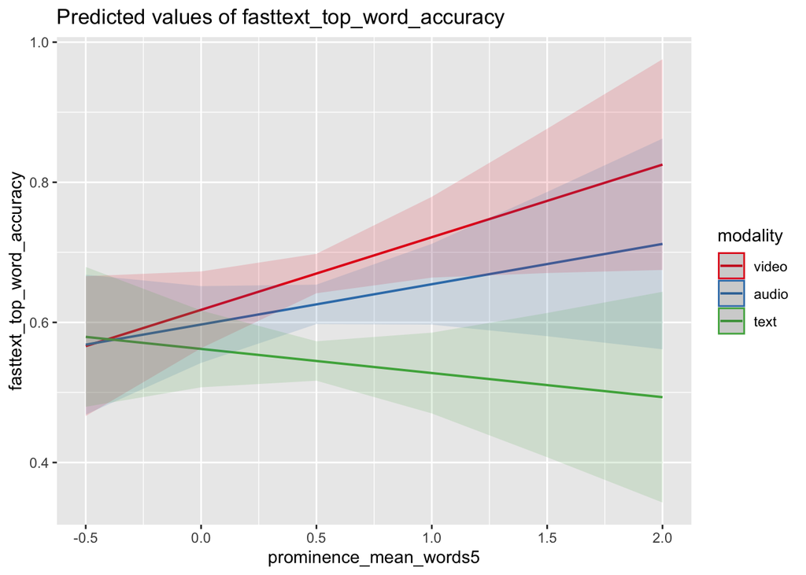

```r
plot_model(model, type='pred', terms=c('prominence_mean_words5', 'modality'))
```

## Analysis 2C - Task-level comparisons (continuous accuracy)

We are also interested in understanding how these effects exist at the level of individual tasks. Since task is a random effect in previous models, we therefore run separate models for each tasks.

We first setup our formula to evaluate our model – we discard task are random-effect as we are inherently testing at the task-level.

```r
continuous_accuracy_formula <- 'fasttext_top_word_accuracy ~ modality + (1|word_index)'
```

#### Story = Black

```r
model <- lmer_task(
  task_name='black',
  df=df_results,
  formula=continuous_accuracy_formula,
)

# Output the results
tab_model(model, show.se=TRUE, show.stat=TRUE, show.r2=TRUE, show.df=TRUE)
```

|  | Dependent variable |  |  |  |  |  |
| --- | --- | --- | --- | --- | --- | --- |
| Predictors | Estimates | std. Error | CI | Statistic | p | df |
| (Intercept) | 0.66 | 0.02 | 0.62 – 0.71 | 28.54 | **<0.001** | 577.00 |
| modality L | -0.11 | 0.02 | -0.14 – -0.08 | -7.29 | **<0.001** | 577.00 |
| modality Q | -0.04 | 0.02 | -0.07 – -0.01 | -2.63 | **0.009** | 577.00 |
| Random Effects |  |  |  |  |  |  |
| σ<sup>2</sup> | 0.05 |  |  |  |  |  |
| τ<sub>00</sub> <sub>word_index</sub> | 0.09 |  |  |  |  |  |
| ICC | 0.66 |  |  |  |  |  |
| N <sub>word_index</sub> | 194 |  |  |  |  |  |
| Observations | 582 |  |  |  |  |  |
| Marginal R<sup>2</sup> / Conditional R<sup>2</sup> | 0.034 / 0.673 |  |  |  |  |  |

```r
# Display results of fixed effects
display_model_summary(model)
```

Model Fixed Effects Summary

| Predictor | Fixed Effects Results Coefficient Estimate | Fixed Effects Results Standard Error | Fixed Effects Results T-Statistic | Fixed Effects Results P-Value | df |  |
| --- | --- | --- | --- | --- | --- | --- |
| (Intercept) | 0.66071800 | 0.02315048 | 28.540146 | 3.513363e-71 |  | 193 |
| modality.L | -0.11165268 | 0.01531848 | -7.288758 | 1.781825e-12 | 386 |  |
| modality.Q | -0.04026152 | 0.01531848 | -2.628298 | 8.923798e-03 | 386 |  |

```r
# Conduct pairwise comparisons between modalities
pairwise_comparisons <- emmeans(model, pairwise ~ modality)
display_pairwise_comparisons(pairwise_comparisons)
```

Pairwise Comparisons

| Comparison Results Comparison | Comparison Results Difference in Mean | Comparison Results Standard Error | Comparison Results Degrees of Freedom | Comparison Results T-Statistic | Comparison Results P-Value |
| --- | --- | --- | --- | --- | --- |
| video - audio | 0.02964027 | 0.0216636 | 386 | 1.368206 | 3.586648e-01 |
| video - text | 0.15790073 | 0.0216636 | 386 | 7.288758 | 0.000000e+00 |
| audio - text | 0.12826046 | 0.0216636 | 386 | 5.920552 | 2.125342e-08 |

#### Story = Smoke

```r
model <- lmer_task(
  task_name='wheretheressmoke',
  df=df_results,
  formula=continuous_accuracy_formula,
)

# Output the results
tab_model(model, show.se=TRUE, show.stat=TRUE, show.r2=TRUE, show.df=TRUE)
```

|  | Dependent variable |  |  |  |  |  |
| --- | --- | --- | --- | --- | --- | --- |
| Predictors | Estimates | std. Error | CI | Statistic | p | df |
| (Intercept) | 0.60 | 0.02 | 0.56 – 0.64 | 28.04 | **<0.001** | 706.00 |
| modality L | -0.10 | 0.01 | -0.12 – -0.07 | -7.37 | **<0.001** | 706.00 |
| modality Q | 0.01 | 0.01 | -0.01 – 0.04 | 1.13 | 0.261 | 706.00 |
| Random Effects |  |  |  |  |  |  |
| σ<sup>2</sup> | 0.04 |  |  |  |  |  |
| τ<sub>00</sub> <sub>word_index</sub> | 0.09 |  |  |  |  |  |
| ICC | 0.69 |  |  |  |  |  |
| N <sub>word_index</sub> | 237 |  |  |  |  |  |
| Observations | 711 |  |  |  |  |  |
| Marginal R<sup>2</sup> / Conditional R<sup>2</sup> | 0.023 / 0.701 |  |  |  |  |  |

```r
# Display results of fixed effects
display_model_summary(model)
```

Model Fixed Effects Summary

| Predictor | Fixed Effects Results Coefficient Estimate | Fixed Effects Results Standard Error | Fixed Effects Results T-Statistic | Fixed Effects Results P-Value | df |  |
| --- | --- | --- | --- | --- | --- | --- |
| (Intercept) | 0.59952102 | 0.02137818 | 28.043591 | 4.341788e-77 |  | 236 |
| modality.L | -0.09759859 | 0.01324639 | -7.367937 | 7.802592e-13 | 472 |  |
| modality.Q | 0.01490691 | 0.01324639 | 1.125356 | 2.610101e-01 | 472 |  |

```r
# Conduct pairwise comparisons between modalities
pairwise_comparisons <- emmeans(model, pairwise ~ modality)
display_pairwise_comparisons(pairwise_comparisons)
```

Pairwise Comparisons

| Comparison Results Comparison | Comparison Results Difference in Mean | Comparison Results Standard Error | Comparison Results Degrees of Freedom | Comparison Results T-Statistic | Comparison Results P-Value |
| --- | --- | --- | --- | --- | --- |
| video - audio | 0.08726978 | 0.01873323 | 472 | 4.658555 | 1.235984e-05 |
| video - text | 0.13802525 | 0.01873323 | 472 | 7.367937 | 3.050160e-11 |
| audio - text | 0.05075547 | 0.01873323 | 472 | 2.709382 | 1.910887e-02 |

#### Story = Draw

```r
model <- lmer_task(
  task_name='howtodraw',
  df=df_results,
  formula=continuous_accuracy_formula,
)

# Output the results
tab_model(model, show.se=TRUE, show.stat=TRUE, show.r2=TRUE, show.df=TRUE)
```

|  | Dependent variable |  |  |  |  |  |
| --- | --- | --- | --- | --- | --- | --- |
| Predictors | Estimates | std. Error | CI | Statistic | p | df |
| (Intercept) | 0.59 | 0.02 | 0.54 – 0.63 | 26.77 | **<0.001** | 718.00 |
| modality L | -0.06 | 0.01 | -0.08 – -0.03 | -4.46 | **<0.001** | 718.00 |
| modality Q | -0.02 | 0.01 | -0.05 – 0.00 | -1.86 | 0.063 | 718.00 |
| Random Effects |  |  |  |  |  |  |
| σ<sup>2</sup> | 0.04 |  |  |  |  |  |
| τ<sub>00</sub> <sub>word_index</sub> | 0.10 |  |  |  |  |  |
| ICC | 0.73 |  |  |  |  |  |
| N <sub>word_index</sub> | 241 |  |  |  |  |  |
| Observations | 723 |  |  |  |  |  |
| Marginal R<sup>2</sup> / Conditional R<sup>2</sup> | 0.009 / 0.736 |  |  |  |  |  |

```r
# Display results of fixed effects
display_model_summary(model)
```

Model Fixed Effects Summary

| Predictor | Fixed Effects Results Coefficient Estimate | Fixed Effects Results Standard Error | Fixed Effects Results T-Statistic | Fixed Effects Results P-Value | df |  |
| --- | --- | --- | --- | --- | --- | --- |
| (Intercept) | 0.58713658 | 0.02193367 | 26.768732 | 5.165633e-74 |  | 240 |
| modality.L | -0.05568728 | 0.01248286 | -4.461100 | 1.016761e-05 | 480 |  |
| modality.Q | -0.02323301 | 0.01248286 | -1.861193 | 6.332797e-02 | 480 |  |

```r
# Conduct pairwise comparisons between modalities
pairwise_comparisons <- emmeans(model, pairwise ~ modality)
display_pairwise_comparisons(pairwise_comparisons)
```

Pairwise Comparisons

| Comparison Results Comparison | Comparison Results Difference in Mean | Comparison Results Standard Error | Comparison Results Degrees of Freedom | Comparison Results T-Statistic | Comparison Results P-Value |
| --- | --- | --- | --- | --- | --- |
| video - audio | 0.01092234 | 0.01765343 | 480 | 0.6187091 | 0.8099472688 |
| video - text | 0.07875370 | 0.01765343 | 480 | 4.4610998 | 0.0000302330 |
| audio - text | 0.06783136 | 0.01765343 | 480 | 3.8423908 | 0.0004056556 |

## Supplementary Analysis - Leakage filtering

We next ensured that our results were not erroneously due to “accidental” leakage of auditory information (e.g., hearing the first phoneme of the upcoming to-be-predicted word).

```r
df_results_filtered <- subset(df_results, !df_results$filter_for_leakage)
```

### Supplementary Analysis 1A - Binary accuracy

```r
binary_accuracy_formula <- 'accuracy ~ modality + (1|word_index:task)'

# Fit the logistic mixed-effects model
model <- glmer(binary_accuracy_formula,
               data = df_results_filtered,
               family = binomial(link = "logit"))

tab_model(model, show.se=TRUE, show.stat=TRUE, show.r2=TRUE, show.df=TRUE)
```

|  | accuracy |  |  |  |  |  |
| --- | --- | --- | --- | --- | --- | --- |
| Predictors | Odds Ratios | std. Error | CI | Statistic | p | df |
| (Intercept) | 0.68 | 0.14 | 0.45 – 1.03 | -1.81 | 0.071 | Inf |
| modality L | 0.26 | 0.04 | 0.19 – 0.35 | -8.57 | **<0.001** | Inf |
| modality Q | 0.76 | 0.11 | 0.58 – 1.00 | -1.95 | 0.051 | Inf |
| Random Effects |  |  |  |  |  |  |
| σ<sup>2</sup> | 3.29 |  |  |  |  |  |
| τ<sub>00</sub> <sub>word_index:task</sub> | 16.38 |  |  |  |  |  |
| ICC | 0.83 |  |  |  |  |  |
| N <sub>word_index</sub> | 537 |  |  |  |  |  |
| N <sub>task</sub> | 3 |  |  |  |  |  |
| Observations | 1803 |  |  |  |  |  |
| Marginal R<sup>2</sup> / Conditional R<sup>2</sup> | 0.032 / 0.838 |  |  |  |  |  |

```r
# Display results of fixed effects
display_model_summary(model)
```

Model Fixed Effects Summary

| Predictor | Fixed Effects Results Coefficient Estimate | Fixed Effects Results Standard Error | Fixed Effects Results Z-Statistic | Fixed Effects Results P-Value |
| --- | --- | --- | --- | --- |
| (Intercept) | -0.3847824 | 0.2129229 | -1.807144 | 7.073979e-02 |
| modality.L | -1.3646629 | 0.1591974 | -8.572144 | 1.015762e-17 |
| modality.Q | -0.2726203 | 0.1397800 | -1.950352 | 5.113413e-02 |

```r
# Conduct pairwise comparisons between modalities
pairwise_comparisons <- emmeans(model, pairwise ~ modality)
display_pairwise_comparisons(pairwise_comparisons)
```

Pairwise Comparisons

| Comparison Results Comparison | Comparison Results Difference in Mean | Comparison Results Standard Error | Comparison Results Degrees of Freedom | Comparison Results Z-Statistic | Comparison Results P-Value |
| --- | --- | --- | --- | --- | --- |
| video - audio | 0.6310722 | 0.1984393 | Inf | 3.180177 | 4.201695e-03 |
| video - text | 1.9299248 | 0.2251391 | Inf | 8.572144 | 2.675637e-14 |
| audio - text | 1.2988527 | 0.2111421 | Inf | 6.151556 | 2.301157e-09 |

### Supplementary Analysis 1B - Binary accuracy prosody interaction

Rerun the logistic regression with the mean prosody included as an interaction effect.

```r
binary_accuracy_formula <- 'accuracy ~ modality * prominence_mean_words5 + (1|word_index:task)'

# Fit the logistic mixed-effects model
model <- glmer(binary_accuracy_formula,
               data = df_results_filtered,
               family = binomial(link = "logit"))

tab_model(model, show.se=TRUE, show.stat=TRUE, show.r2=TRUE, show.df=TRUE)
```

|  | accuracy |  |  |  |  |  |
| --- | --- | --- | --- | --- | --- | --- |
| Predictors | Odds Ratios | std. Error | CI | Statistic | p | df |
| (Intercept) | 0.69 | 0.29 | 0.30 – 1.57 | -0.89 | 0.375 | Inf |
| modality L | 0.51 | 0.15 | 0.28 – 0.91 | -2.27 | **0.023** | Inf |
| modality Q | 0.84 | 0.23 | 0.49 – 1.45 | -0.62 | 0.535 | Inf |
| prominence mean words5 | 0.96 | 0.71 | 0.22 – 4.13 | -0.05 | 0.958 | Inf |
| modality L × prominence mean words5 | 0.23 | 0.13 | 0.07 – 0.69 | -2.61 | **0.009** | Inf |
| modality Q × prominence mean words5 | 0.80 | 0.41 | 0.30 – 2.18 | -0.43 | 0.669 | Inf |
| Random Effects |  |  |  |  |  |  |
| σ<sup>2</sup> | 3.29 |  |  |  |  |  |
| τ<sub>00</sub> <sub>word_index:task</sub> | 16.78 |  |  |  |  |  |
| ICC | 0.84 |  |  |  |  |  |
| N <sub>word_index</sub> | 537 |  |  |  |  |  |
| N <sub>task</sub> | 3 |  |  |  |  |  |
| Observations | 1803 |  |  |  |  |  |
| Marginal R<sup>2</sup> / Conditional R<sup>2</sup> | 0.035 / 0.842 |  |  |  |  |  |

```r
summary (model)
```

```
## Generalized linear mixed model fit by maximum likelihood (Laplace
##   Approximation) [glmerMod]
##  Family: binomial  ( logit )
## Formula: accuracy ~ modality * prominence_mean_words5 + (1 | word_index:task)
##    Data: df_results_filtered
##
##      AIC      BIC   logLik deviance df.resid
##   1846.6   1885.1   -916.3   1832.6     1796
##
## Scaled residuals:
##     Min      1Q  Median      3Q     Max
## -2.3989 -0.2784 -0.1039  0.3411  3.6125
##
## Random effects:
##  Groups          Name        Variance Std.Dev.
##  word_index:task (Intercept) 16.78    4.096
## Number of obs: 1803, groups:  word_index:task, 601
##
## Fixed effects:
##                                   Estimate Std. Error z value Pr(>|z|)
## (Intercept)                       -0.37136    0.41881  -0.887  0.37524
## modality.L                        -0.67613    0.29827  -2.267  0.02340 *
## modality.Q                        -0.17308    0.27883  -0.621  0.53476
## prominence_mean_words5            -0.03919    0.74337  -0.053  0.95795
## modality.L:prominence_mean_words5 -1.48175    0.56879  -2.605  0.00919 **
## modality.Q:prominence_mean_words5 -0.21782    0.50918  -0.428  0.66881
## ---
## Signif. codes:  0 '***' 0.001 '**' 0.01 '*' 0.05 '.' 0.1 ' ' 1
##
## Correlation of Fixed Effects:
##             (Intr) mdlt.L mdlt.Q prm__5 m.L:__
## modality.L   0.004
## modality.Q   0.008  0.039
## prmnnc_mn_5 -0.857  0.006 -0.004
## mdlty.L:__5  0.020 -0.843 -0.036 -0.010
## mdlty.Q:__5 -0.001 -0.038 -0.863  0.003  0.059
```

### Supplementary Analysis 2A - Continuous accuracy

```r
continuous_accuracy_formula <- 'fasttext_top_word_accuracy ~ modality + (1|word_index:task)'

# Fit the logistic mixed-effects model
model <- lmer(continuous_accuracy_formula, data = df_results_filtered)

tab_model(model, show.se=TRUE, show.stat=TRUE, show.r2=TRUE, show.df=TRUE)
```

|  | fasttext_top_word_accuracy |  |  |  |  |  |
| --- | --- | --- | --- | --- | --- | --- |
| Predictors | Estimates | std. Error | CI | Statistic | p | df |
| (Intercept) | 0.63 | 0.01 | 0.60 – 0.65 | 45.83 | **<0.001** | 1798.00 |
| modality L | -0.08 | 0.01 | -0.10 – -0.07 | -10.03 | **<0.001** | 1798.00 |
| modality Q | -0.01 | 0.01 | -0.03 – 0.00 | -1.64 | 0.101 | 1798.00 |
| Random Effects |  |  |  |  |  |  |
| σ<sup>2</sup> | 0.04 |  |  |  |  |  |
| τ<sub>00</sub> <sub>word_index:task</sub> | 0.10 |  |  |  |  |  |
| ICC | 0.71 |  |  |  |  |  |
| N <sub>word_index</sub> | 537 |  |  |  |  |  |
| N <sub>task</sub> | 3 |  |  |  |  |  |
| Observations | 1803 |  |  |  |  |  |
| Marginal R<sup>2</sup> / Conditional R<sup>2</sup> | 0.016 / 0.713 |  |  |  |  |  |

```r
# Display results of fixed effects
display_model_summary(model)
```

Model Fixed Effects Summary

| Predictor | Fixed Effects Results Coefficient Estimate | Fixed Effects Results Standard Error | Fixed Effects Results T-Statistic | Fixed Effects Results P-Value | df |  |
| --- | --- | --- | --- | --- | --- | --- |
| (Intercept) | 0.62554908 | 0.013648925 | 45.831380 | 3.788070e-198 |  | 600 |
| modality.L | -0.08234671 | 0.008208079 | -10.032397 | 8.441313e-23 | 1200 |  |
| modality.Q | -0.01345432 | 0.008208079 | -1.639155 | 1.014430e-01 | 1200 |  |

```r
# Conduct pairwise comparisons between modalities
pairwise_comparisons <- emmeans(model, pairwise ~ modality)
display_pairwise_comparisons(pairwise_comparisons)
```

Pairwise Comparisons

| Comparison Results Comparison | Comparison Results Difference in Mean | Comparison Results Standard Error | Comparison Results Degrees of Freedom | Comparison Results T-Statistic | Comparison Results P-Value |
| --- | --- | --- | --- | --- | --- |
| video - audio | 0.04174981 | 0.01160798 | 1200 | 3.596648 | 9.774648e-04 |
| video - text | 0.11645583 | 0.01160798 | 1200 | 10.032397 | 1.952882e-13 |
| audio - text | 0.07470602 | 0.01160798 | 1200 | 6.435749 | 5.316786e-10 |

### Supplementary Analysis 2B - Continuous accuracy w/ prosody interaction

```r
continuous_accuracy_formula <- 'fasttext_top_word_accuracy ~ modality * prominence_mean_words5 + (1|word_index:task)'

# Fit the logistic mixed-effects model
model <- lmer(continuous_accuracy_formula, data = df_results_filtered)

tab_model(model, show.se=TRUE, show.stat=TRUE, show.r2=TRUE, show.df=TRUE)
```

|  | fasttext_top_word_accuracy |  |  |  |  |  |
| --- | --- | --- | --- | --- | --- | --- |
| Predictors | Estimates | std. Error | CI | Statistic | p | df |
| (Intercept) | 0.62 | 0.03 | 0.57 – 0.67 | 23.19 | **<0.001** | 1795.00 |
| modality L | -0.05 | 0.02 | -0.08 – -0.01 | -2.87 | **0.004** | 1795.00 |
| modality Q | -0.01 | 0.02 | -0.04 – 0.02 | -0.68 | 0.495 | 1795.00 |
| prominence mean words5 | 0.01 | 0.05 | -0.08 – 0.11 | 0.25 | 0.802 | 1795.00 |
| modality L × prominence mean words5 | -0.08 | 0.03 | -0.13 – -0.02 | -2.63 | **0.009** | 1795.00 |
| modality Q × prominence mean words5 | -0.01 | 0.03 | -0.06 – 0.05 | -0.18 | 0.855 | 1795.00 |
| Random Effects |  |  |  |  |  |  |
| σ<sup>2</sup> | 0.04 |  |  |  |  |  |
| τ<sub>00</sub> <sub>word_index:task</sub> | 0.10 |  |  |  |  |  |
| ICC | 0.71 |  |  |  |  |  |
| N <sub>word_index</sub> | 537 |  |  |  |  |  |
| N <sub>task</sub> | 3 |  |  |  |  |  |
| Observations | 1803 |  |  |  |  |  |
| Marginal R<sup>2</sup> / Conditional R<sup>2</sup> | 0.018 / 0.715 |  |  |  |  |  |

```r
# Display results of fixed effects
display_model_summary(model)
```

Model Fixed Effects Summary

| Predictor | Fixed Effects Results Coefficient Estimate | Fixed Effects Results Standard Error | Fixed Effects Results T-Statistic | Fixed Effects Results P-Value | df |  |
| --- | --- | --- | --- | --- | --- | --- |
| (Intercept) | 0.619791028 | 0.02673226 | 23.1851333 | 2.319242e-85 |  | 599 |
| modality.L | -0.046067182 | 0.01603034 | -2.8737502 | 4.127913e-03 | 1198 |  |
| modality.Q | -0.010932099 | 0.01603034 | -0.6819631 | 4.953941e-01 | 1198 |  |
| prominence_mean_words5 | 0.012098518 | 0.04828206 | 0.2505800 | 8.022248e-01 | 599 |  |
| modality.L:prominence_mean_words5 | -0.076228685 | 0.02895294 | -2.6328476 | 8.576170e-03 | 1198 |  |
| modality.Q:prominence_mean_words5 | -0.005299556 | 0.02895294 | -0.1830403 | 8.547974e-01 | 1198 |  |

```r
# Conduct pairwise comparisons between modalities
pairwise_comparisons <- emmeans(model, pairwise ~ modality)
```

```
## NOTE: Results may be misleading due to involvement in interactions
```

```r
display_pairwise_comparisons(pairwise_comparisons)
```

Pairwise Comparisons

| Comparison Results Comparison | Comparison Results Difference in Mean | Comparison Results Standard Error | Comparison Results Degrees of Freedom | Comparison Results T-Statistic | Comparison Results P-Value |
| --- | --- | --- | --- | --- | --- |
| video - audio | 0.04174981 | 0.01158403 | 1198 | 3.604082 | 9.505527e-04 |
| video - text | 0.11645583 | 0.01158403 | 1198 | 10.053132 | 0.000000e+00 |
| audio - text | 0.07470602 | 0.01158403 | 1198 | 6.449050 | 4.882650e-10 |

#### Plot the model

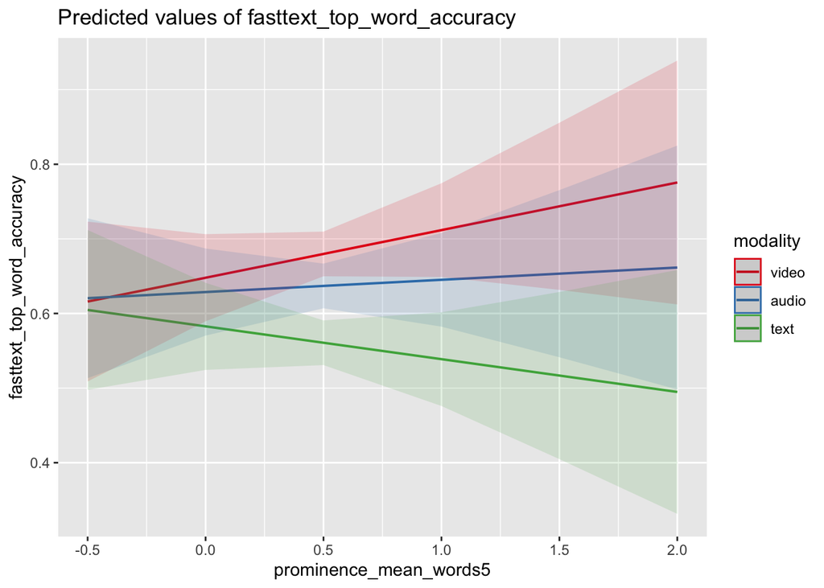

```r
plot_model(model, type='pred', terms=c('prominence_mean_words5', 'modality'))
```